# Replication project

Frank Azorsa

11/29/2019

1. Title: Polymorphism and division of labour in a socially complex ant: neuromodulaton of aggression in the Australian weaver ant, Oecophylla smaragdina
2. Authors: J. Frances Kamhi, Kelley Nunn, Simon K. A. Robson and James F. A. Traniello.
3. Goal: The authors tested the hypothesis that division of labour by morphologically differentiated workers in complex insect societies is regulated by biogenic amines. They examined variation in levels of monoamines between O. smaragdina minor and major workers and determined their role in controlling subcaste-specific differences in aggressive behaviours associated with territorial defence.

[figure not shown]

*Oecophylla smaragdina*

4. Dataset: The datasets used to replicate the result of this article have been downloaded from Dryad: doi:10.5061/dryad.36s2m.
5. Analysis: Summary statistics are presented as mean +/- 95% confidence intervals and all statistical analysis were performed using JMP PRO 11 statistical software. Aggression scores and the frequency of behaviours in response categories (non-aggressive behaviours, olfactory assessment and aggressive actions) of subcaste or treatment groups were compared using non-parametric Mann – Whitney U-tests. Simple linear regression analyses were used to determine the relationship between amine titre and the natural log of the frequency of behaviours in each category. Biogenic amine titres and movement assays were compared with Student’s t-tests.

```r
#Replication project notes: Here I mainly replicate all figures, and performed non-parametric Mann – Whitney U-tests. First I installed the following packages and their dependencies: ggplot2, car, curl, dplyr, tidyr, reshape2.
```

```r
library(curl)
library(car)
```

```r
library(ggplot2)
```

### Figure 1 a, b

5.1 Data preparation: As mentioned previously, all data are available for download from the supplementary material of Kamhi et al. (2015), or more specifically from a Dryad repository. We can download the data table directly into R: ####Figure 1. Average aggression scores (a,c) and frequency of responses in three behavioural categories (b,d) are presented for intraspecific assays (a,b) and interspecific assays (c,d) for major and minor workers.

```r
e <- read.csv("https://raw.githubusercontent.com/frankazorsa/AN597_replication-project/master/intrasp_assays.csv?token=ANEFADSOQH3RRWFFKEIT5JS57AXYO")
e
```

```
##       ID date.tested subcaste focal.colony stimulus.colony avoid no.response
## 1   maj1     5_30_13    major       JC_B13          JC_D13     0           0
## 2   maj2     5_30_13    major       JC_B13          JC_D13     0           0
## 3   maj3     5_30_13    major       JC_B13          JC_D13    20           0
## 4   maj4     5_30_13    major       JC_B13          JC_D13     0           0
## 5   min1     5_30_13    minor       JC_B13          JC_D13     1           0
## 6   min2     5_30_13    minor       JC_B13          JC_D13     6           0
## 7   min3     5_31_13    minor       JC_B13          JC_D13     3           0
## 8   min4     5_31_13    minor       JC_B13          JC_D13     0           0
## 9   min5     5_31_13    minor       JC_B13          JC_D13     2           0
## 10  min6     5_31_13    minor       JC_B13          JC_D13     3           0
## 11  min7     5_31_13    minor       JC_B13          JC_D13     0           0
## 12  min8     5_31_13    minor       JC_B13          JC_D13     2           0
## 13  maj5     5_31_13    major       JC_B13          JC_D13    20           0
## 14  maj6     5_31_13    major       JC_B13          JC_D13     1           0
```

[output cut: 67 more lines]

```r
class(e)#check the data type of the object e.
```

```
## [1] "data.frame"
```

```r
names(e)#column names
```

```
##  [1] "ID"              "date.tested"     "subcaste"        "focal.colony"
##  [5] "stimulus.colony" "avoid"           "no.response"     "antennation"
##  [9] "flared"          "raised.gaster"   "lunge"           "bite"
## [13] "non.agg.freq"    "agg.freq"        "agg.metric"
```

```r
count <- table(e$subcaste)#count the number of major and minor workers
count
```

```
##
## major minor
##    20    20
```

### Figure 1a

```r
library(dplyr)
```

```r
library(ggplot2)
cleandata <- e %>%
  group_by (subcaste) %>%
  summarise (mean_agg.metric = mean(agg.metric, na.rm = TRUE), sd_agg.metric =sd(agg.metric, na.rm = TRUE), count=n(), se_agg.metric =(sd_agg.metric/(sqrt(count))))
cleandata
```

```
## # A tibble: 2 x 5
##   subcaste mean_agg.metric sd_agg.metric count se_agg.metric
##   <fct>              <dbl>         <dbl> <int>         <dbl>
## 1 major               2.57         0.945    20         0.211
## 2 minor               2.18         0.649    20         0.145
```

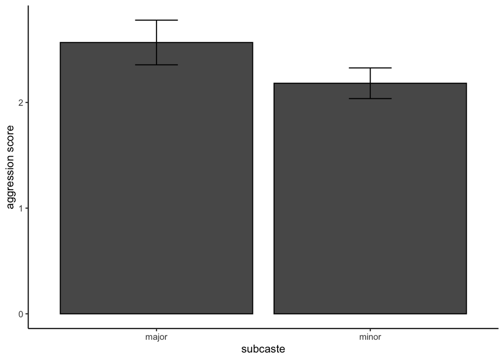

```r
Lab2Plot <- ggplot(cleandata, aes(x = subcaste, y=mean_agg.metric)) +
  geom_bar(stat = "identity", color = "black",
           position = position_dodge()) +
  geom_errorbar(aes(ymin = mean_agg.metric-se_agg.metric, ymax = mean_agg.metric + se_agg.metric), width = .2) +
  labs(x ="subcaste", y = "aggression score") +
  theme_classic()

Lab2Plot
```

### Figure 1b

```r
library(dplyr)
library(ggplot2)
cleandata2 <- e %>%
  group_by (subcaste) %>%
  summarise (mean_non.agg.freq = mean(non.agg.freq, na.rm = TRUE),
             mean_antennation = mean(antennation, na.rm = TRUE),
             mean_agg.freq = mean(agg.freq, na.rm = TRUE),
             sd_non.agg.freq = sd(non.agg.freq, na.rm = TRUE),
             sd_antennation = sd(antennation, na.rm = TRUE),
             sd_agg.freq = sd(agg.freq, na.rm = TRUE),
             count=n(),
             se_non.agg.freq = (sd_non.agg.freq/(sqrt(count))),
             se_antennation = (sd_antennation/(sqrt(count))),
             se_agg.freq = (sd_agg.freq/(sqrt(count))))
cleandata2
```

```
## # A tibble: 2 x 11
##   subcaste mean_non.agg.fr… mean_antennation mean_agg.freq sd_non.agg.freq
##   <fct>               <dbl>            <dbl>         <dbl>           <dbl>
## 1 major                2.7               7.2          3.1             6.26
## 2 minor                1.05              6.8          1.25            1.64
## # … with 6 more variables: sd_antennation <dbl>, sd_agg.freq <dbl>,
## #   count <int>, se_non.agg.freq <dbl>, se_antennation <dbl>, se_agg.freq <dbl>
```

```r
means4 <- aggregate(cleandata2, by=list(cleandata2$subcaste), mean)
means4
```

```
##   Group.1 subcaste mean_non.agg.freq mean_antennation mean_agg.freq
## 1   major       NA              2.70              7.2          3.10
## 2   minor       NA              1.05              6.8          1.25
##   sd_non.agg.freq sd_antennation sd_agg.freq count se_non.agg.freq
## 1        6.258468       5.800181    3.210181    20       1.3994360
## 2        1.637553       7.837830    2.268201    20       0.3661679
##   se_antennation se_agg.freq
## 1       1.296960   0.7178183
## 2       1.752592   0.5071852
```

```r
means4$subcaste <- NULL
means4
```

```
##   Group.1 mean_non.agg.freq mean_antennation mean_agg.freq sd_non.agg.freq
## 1   major              2.70              7.2          3.10        6.258468
## 2   minor              1.05              6.8          1.25        1.637553
##   sd_antennation sd_agg.freq count se_non.agg.freq se_antennation se_agg.freq
## 1       5.800181    3.210181    20       1.3994360       1.296960   0.7178183
## 2       7.837830    2.268201    20       0.3661679       1.752592   0.5071852
```

```r
names(means4)[names(means4) == 'Group.1'] <- 'subcaste'
means4
```

```
##   subcaste mean_non.agg.freq mean_antennation mean_agg.freq sd_non.agg.freq
## 1    major              2.70              7.2          3.10        6.258468
## 2    minor              1.05              6.8          1.25        1.637553
##   sd_antennation sd_agg.freq count se_non.agg.freq se_antennation se_agg.freq
## 1       5.800181    3.210181    20       1.3994360       1.296960   0.7178183
## 2       7.837830    2.268201    20       0.3661679       1.752592   0.5071852
```

```r
dataset <- means4[1:4]
dataset
```

```
##   subcaste mean_non.agg.freq mean_antennation mean_agg.freq
## 1    major              2.70              7.2          3.10
## 2    minor              1.05              6.8          1.25
```

```r
names(dataset)
```

```
## [1] "subcaste"          "mean_non.agg.freq" "mean_antennation"
## [4] "mean_agg.freq"
```

```r
data(dataset)
```

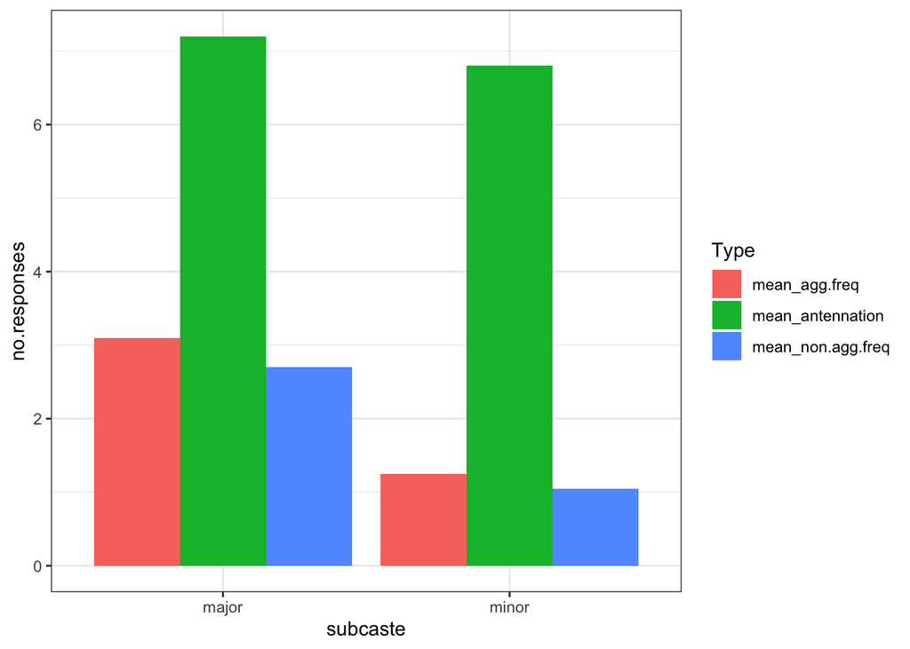

```r
library(ggplot2)
library(tidyr)
dataset %>%
  gather("Type", "no.responses",-subcaste) %>%
  ggplot(aes(subcaste, no.responses, fill = Type)) +
  geom_bar(position = "dodge", stat = "identity") +
  theme_bw()
```

### Figure 1 c,d

```r
f <- read.csv("https://raw.githubusercontent.com/frankazorsa/AN597_replication-project/master/intersp_assays.csv?token=ANEFADRF5N5SD377F34LQQ257AX3C")
f
```

```
##       ID subcaste focal.colony head.width..mm. estimated.brain.mass
## 1  min28    minor         OS-1              NA                   NA
## 2  min29    minor         OS-1              NA                   NA
## 3  min30    minor         OS-1              NA                   NA
## 4  min31    minor         OS-1              NA                   NA
## 5  min32    minor         OS-1              NA                   NA
## 6  min33    minor         OS-1              NA                   NA
## 7  min35    minor         OS-1              NA                   NA
## 8  min36    minor         OS-1              NA                   NA
## 9   maj1    major       OS-TC5        1.526316             61.22368
## 10  min1    minor       OS-TC5        1.026316             45.57368
## 11  min2    minor       OS-TC5        1.052632             46.39737
## 12  maj2    major       OS-TC5              NA                   NA
## 13  maj3    major       OS-TC5        1.631579             64.51842
## 14  min3    minor       OS-TC5        1.078947             47.22105
```

[output cut: 153 more lines]

```r
class(f)
```

```
## [1] "data.frame"
```

```r
names(f)
```

```
##  [1] "ID"                   "subcaste"             "focal.colony"
##  [4] "head.width..mm."      "estimated.brain.mass" "DA.corrected"
##  [7] "DA.brain.mass"        "X5.HT.corrected"      "X5.HT.brain.mass"
## [10] "OA.corrected"         "OA.brain.mass"        "avoid"
## [13] "no.response"          "antennation"          "flared"
## [16] "raised.gaster"        "lunge"                "bite"
## [19] "non.agg.freq"         "agg.freq"             "agg.metric"
```

```r
count <- table(f$subcaste)
count
```

```
##
## major minor
##    17    24
```

### Figure 1 c

```r
library(dplyr)
library(ggplot2)
cleandata <- f %>%
  group_by (subcaste) %>%
  summarise (mean_agg.metric = mean(agg.metric, na.rm = TRUE), sd_agg.metric =sd(agg.metric, na.rm = TRUE), count=n(), se_agg.metric =(sd_agg.metric/(sqrt(count))))
cleandata
```

```
## # A tibble: 2 x 5
##   subcaste mean_agg.metric sd_agg.metric count se_agg.metric
##   <fct>              <dbl>         <dbl> <int>         <dbl>
## 1 major               3.50          1.18    17         0.286
## 2 minor               1.76          1.22    24         0.248
```

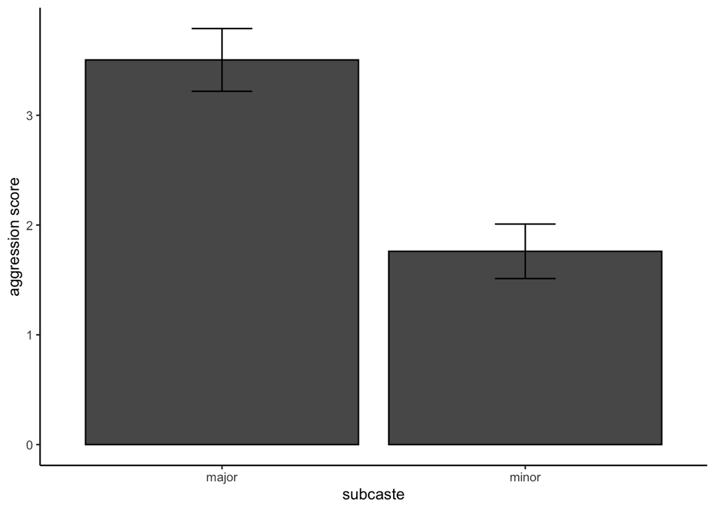

```r
Lab1Plot <- ggplot(cleandata, aes(x = subcaste, y=mean_agg.metric)) +
  geom_bar(stat = "identity", color = "black",
           position = position_dodge()) +
  geom_errorbar(aes(ymin = mean_agg.metric-se_agg.metric, ymax = mean_agg.metric + se_agg.metric), width = .2) +
  labs(x ="subcaste", y = "aggression score") +
  theme_classic()

Lab1Plot
```

# Figure 1 d

```r
library(dplyr)
library(ggplot2)
cleandata1 <- f %>%
  group_by (subcaste) %>%
  summarise (mean_non.agg.freq = mean(non.agg.freq, na.rm = TRUE),
             mean_antennation = mean(antennation, na.rm = TRUE),
             mean_agg.freq = mean(agg.freq, na.rm = TRUE),
             sd_non.agg.freq = sd(non.agg.freq, na.rm = TRUE),
             sd_antennation = sd(antennation, na.rm = TRUE),
             sd_agg.freq = sd(agg.freq, na.rm = TRUE),
             count=n(),
             se_non.agg.freq = (sd_non.agg.freq/(sqrt(count))),
             se_antennation = (sd_antennation/(sqrt(count))),
             se_agg.freq = (sd_agg.freq/(sqrt(count))))
cleandata1
```

```
## # A tibble: 2 x 11
##   subcaste mean_non.agg.fr… mean_antennation mean_agg.freq sd_non.agg.freq
##   <fct>               <dbl>            <dbl>         <dbl>           <dbl>
## 1 major                5.24             4.24          8.76            6.18
## 2 minor                9                3.46          2.71            9.85
## # … with 6 more variables: sd_antennation <dbl>, sd_agg.freq <dbl>,
## #   count <int>, se_non.agg.freq <dbl>, se_antennation <dbl>, se_agg.freq <dbl>
```

```r
means <- aggregate(cleandata1, by=list(cleandata1$subcaste), mean)
means
```

```
##   Group.1 subcaste mean_non.agg.freq mean_antennation mean_agg.freq
## 1   major       NA          5.235294         4.235294      8.764706
## 2   minor       NA          9.000000         3.458333      2.708333
##   sd_non.agg.freq sd_antennation sd_agg.freq count se_non.agg.freq
## 1        6.179901       4.131123    5.178434    17        1.498846
## 2        9.851065       3.438644    2.999698    24        2.010840
##   se_antennation se_agg.freq
## 1      1.0019445   1.2559547
## 2      0.7019104   0.6123108
```

```r
means$subcaste <- NULL
means
```

```
##   Group.1 mean_non.agg.freq mean_antennation mean_agg.freq sd_non.agg.freq
## 1   major          5.235294         4.235294      8.764706        6.179901
## 2   minor          9.000000         3.458333      2.708333        9.851065
##   sd_antennation sd_agg.freq count se_non.agg.freq se_antennation se_agg.freq
## 1       4.131123    5.178434    17        1.498846      1.0019445   1.2559547
## 2       3.438644    2.999698    24        2.010840      0.7019104   0.6123108
```

```r
names(means)[names(means) == 'Group.1'] <- 'subcaste'
means
```

```
##   subcaste mean_non.agg.freq mean_antennation mean_agg.freq sd_non.agg.freq
## 1    major          5.235294         4.235294      8.764706        6.179901
## 2    minor          9.000000         3.458333      2.708333        9.851065
##   sd_antennation sd_agg.freq count se_non.agg.freq se_antennation se_agg.freq
## 1       4.131123    5.178434    17        1.498846      1.0019445   1.2559547
## 2       3.438644    2.999698    24        2.010840      0.7019104   0.6123108
```

```r
dataset <- means[1:4]
dataset
```

```
##   subcaste mean_non.agg.freq mean_antennation mean_agg.freq
## 1    major          5.235294         4.235294      8.764706
## 2    minor          9.000000         3.458333      2.708333
```

```r
names(dataset)
```

```
## [1] "subcaste"          "mean_non.agg.freq" "mean_antennation"
## [4] "mean_agg.freq"
```

```r
data(dataset)
```

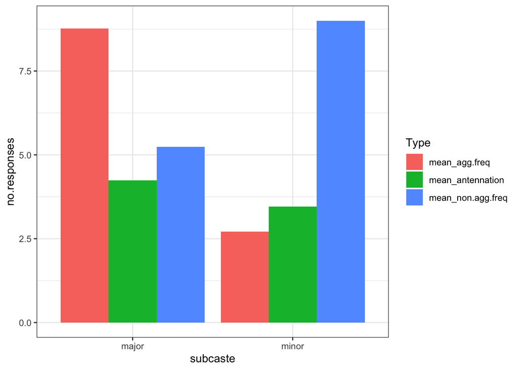

```r
library(ggplot2)
library(tidyr)
dataset %>%
  gather("Type", "no.responses",-subcaste) %>%
  ggplot(aes(subcaste, no.responses, fill = Type)) +
  geom_bar(position = "dodge", stat = "identity") +
  theme_bw()
```

#### Figure 3. Mean of dopamine (DA), serotonin (5-HT) and octopamine (OA) brain titres for estimated brain mass for minors and majors. *Error bars are not included.

```r
library(dplyr)
library(ggplot2)
cleandata4 <- f %>%
  group_by (subcaste) %>%
  summarise (mean_DA.brain.mass = mean(DA.brain.mass, na.rm = TRUE),
             mean_X5.HT.brain.mass = mean(X5.HT.brain.mass, na.rm = TRUE),
             mean_OA.brain.mass = mean(OA.brain.mass, na.rm = TRUE),
             sd_DA.brain.mass = sd(DA.brain.mass, na.rm = TRUE),
             sd_X5.HT.brain.mass = sd(X5.HT.brain.mass, na.rm = TRUE),
             sd_OA.brain.mass = sd(OA.brain.mass, na.rm = TRUE),
             count=n(),
             se_DA.brain.mass = (sd_DA.brain.mass/(sqrt(count))),
             se_X5.HT.brain.mass = (sd_X5.HT.brain.mass/(sqrt(count))),
             se_OA.brain.mass = (sd_OA.brain.mass/(sqrt(count))))
cleandata4
```

```
## # A tibble: 2 x 11
##   subcaste mean_DA.brain.m… mean_X5.HT.brai… mean_OA.brain.m… sd_DA.brain.mass
##   <fct>               <dbl>            <dbl>            <dbl>            <dbl>
## 1 major                10.8             6.35             4.73             1.58
## 2 minor                10.9             6.52             3.89             1.59
## # … with 6 more variables: sd_X5.HT.brain.mass <dbl>, sd_OA.brain.mass <dbl>,
## #   count <int>, se_DA.brain.mass <dbl>, se_X5.HT.brain.mass <dbl>,
## #   se_OA.brain.mass <dbl>
```

```r
means1 <- aggregate(cleandata4, by=list(cleandata4$subcaste), mean)
means1
```

```
##   Group.1 subcaste mean_DA.brain.mass mean_X5.HT.brain.mass mean_OA.brain.mass
## 1   major       NA           10.78942              6.354643           4.726405
## 2   minor       NA           10.86663              6.519908           3.887229
##   sd_DA.brain.mass sd_X5.HT.brain.mass sd_OA.brain.mass count se_DA.brain.mass
## 1         1.576805           0.3967921        0.5036466    17        0.3824315
## 2         1.590505           0.4785852        0.3310922    24        0.3246605
##   se_X5.HT.brain.mass se_OA.brain.mass
## 1          0.09623622       0.12215225
## 2          0.09769080       0.06758391
```

```r
means1$subcaste <- NULL
means1
```

```
##   Group.1 mean_DA.brain.mass mean_X5.HT.brain.mass mean_OA.brain.mass
## 1   major           10.78942              6.354643           4.726405
## 2   minor           10.86663              6.519908           3.887229
##   sd_DA.brain.mass sd_X5.HT.brain.mass sd_OA.brain.mass count se_DA.brain.mass
## 1         1.576805           0.3967921        0.5036466    17        0.3824315
## 2         1.590505           0.4785852        0.3310922    24        0.3246605
##   se_X5.HT.brain.mass se_OA.brain.mass
## 1          0.09623622       0.12215225
## 2          0.09769080       0.06758391
```

```r
names(means1)[names(means1) == 'Group.1'] <- 'subcaste'
means1
```

```
##   subcaste mean_DA.brain.mass mean_X5.HT.brain.mass mean_OA.brain.mass
## 1    major           10.78942              6.354643           4.726405
## 2    minor           10.86663              6.519908           3.887229
##   sd_DA.brain.mass sd_X5.HT.brain.mass sd_OA.brain.mass count se_DA.brain.mass
## 1         1.576805           0.3967921        0.5036466    17        0.3824315
## 2         1.590505           0.4785852        0.3310922    24        0.3246605
##   se_X5.HT.brain.mass se_OA.brain.mass
## 1          0.09623622       0.12215225
## 2          0.09769080       0.06758391
```

```r
dataset1 <- means1[1:4]
dataset1
```

```
##   subcaste mean_DA.brain.mass mean_X5.HT.brain.mass mean_OA.brain.mass
## 1    major           10.78942              6.354643           4.726405
## 2    minor           10.86663              6.519908           3.887229
```

```r
names(dataset1)
```

```
## [1] "subcaste"              "mean_DA.brain.mass"    "mean_X5.HT.brain.mass"
## [4] "mean_OA.brain.mass"
```

```r
library(reshape2)
```

```r
library(ggplot2)
dataset1
```

```
##   subcaste mean_DA.brain.mass mean_X5.HT.brain.mass mean_OA.brain.mass
## 1    major           10.78942              6.354643           4.726405
## 2    minor           10.86663              6.519908           3.887229
```

```r
data.m <- melt(dataset1, id.vars='subcaste')
data.m
```

```
##   subcaste              variable     value
## 1    major    mean_DA.brain.mass 10.789419
## 2    minor    mean_DA.brain.mass 10.866625
## 3    major mean_X5.HT.brain.mass  6.354643
## 4    minor mean_X5.HT.brain.mass  6.519908
## 5    major    mean_OA.brain.mass  4.726405
## 6    minor    mean_OA.brain.mass  3.887229
```

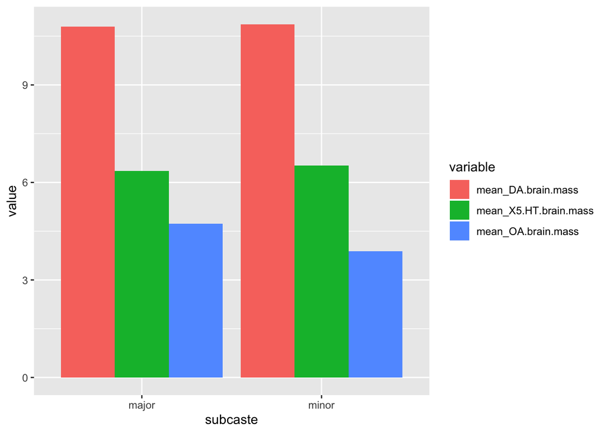

```r
ggplot(data = data.m, aes(x = subcaste, y = value, fill = variable)) +
       geom_bar(stat = 'identity', position = 'dodge')
```

```r
attach(f)
names(f)
```

```
##  [1] "ID"                   "subcaste"             "focal.colony"
##  [4] "head.width..mm."      "estimated.brain.mass" "DA.corrected"
##  [7] "DA.brain.mass"        "X5.HT.corrected"      "X5.HT.brain.mass"
## [10] "OA.corrected"         "OA.brain.mass"        "avoid"
## [13] "no.response"          "antennation"          "flared"
## [16] "raised.gaster"        "lunge"                "bite"
## [19] "non.agg.freq"         "agg.freq"             "agg.metric"
```

```r
reg0 <- lm(non.agg.freq~DA.brain.mass, data = f)
summary(reg0)
```

```
##
## Call:
## lm(formula = non.agg.freq ~ DA.brain.mass, data = f)
##
## Residuals:
##    Min     1Q Median     3Q    Max
## -5.550 -4.542 -1.886  1.865 18.115
##
## Coefficients:
##               Estimate Std. Error t value Pr(>|t|)
## (Intercept)    14.2001     8.0239   1.770   0.0877 .
## DA.brain.mass  -0.8343     0.7337  -1.137   0.2652
## ---
## Signif. codes:  0 '***' 0.001 '**' 0.01 '*' 0.05 '.' 0.1 ' ' 1
##
## Residual standard error: 6.151 on 28 degrees of freedom
##   (11 observations deleted due to missingness)
## Multiple R-squared:  0.04413,    Adjusted R-squared:  0.009995
## F-statistic: 1.293 on 1 and 28 DF,  p-value: 0.2652
```

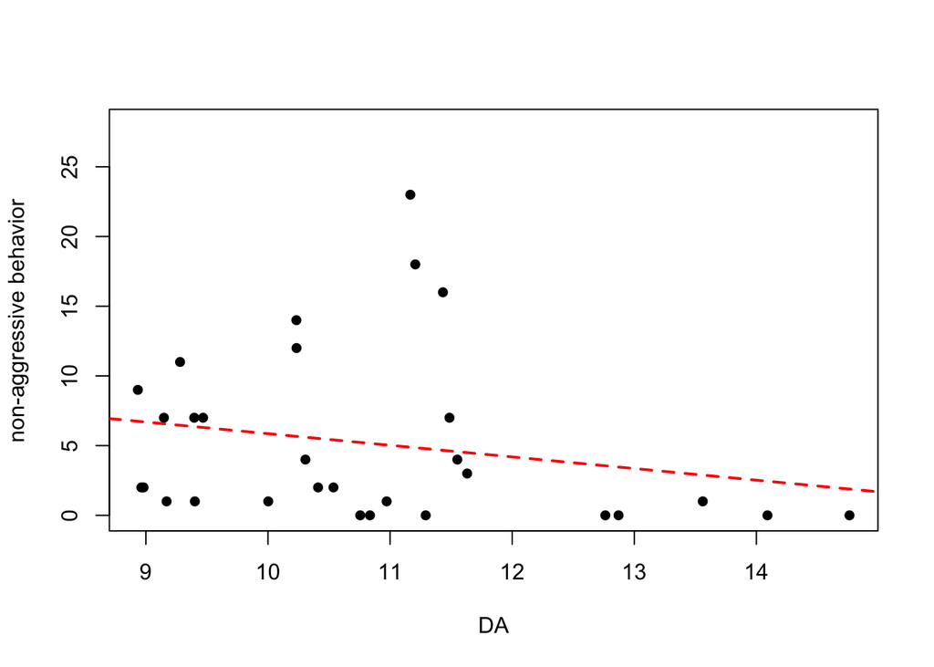

```r
plot(DA.brain.mass, non.agg.freq,pch=16,
               xlab="DA",
               ylab="non-aggressive behavior")
abline(coefficients(reg0), lwd=2, lty=2,
       col="red")
```

```r
reg1 <- lm(non.agg.freq~X5.HT.brain.mass, data = f)
summary(reg1)
```

```
##
## Call:
## lm(formula = non.agg.freq ~ X5.HT.brain.mass, data = f)
##
## Residuals:
##    Min     1Q Median     3Q    Max
## -5.260 -4.526 -2.908  2.537 18.057
##
## Coefficients:
##                  Estimate Std. Error t value Pr(>|t|)
## (Intercept)        13.703     17.051   0.804    0.428
## X5.HT.brain.mass   -1.326      2.643  -0.502    0.620
##
## Residual standard error: 6.263 on 28 degrees of freedom
##   (11 observations deleted due to missingness)
## Multiple R-squared:  0.008911,   Adjusted R-squared:  -0.02648
## F-statistic: 0.2518 on 1 and 28 DF,  p-value: 0.6198
```

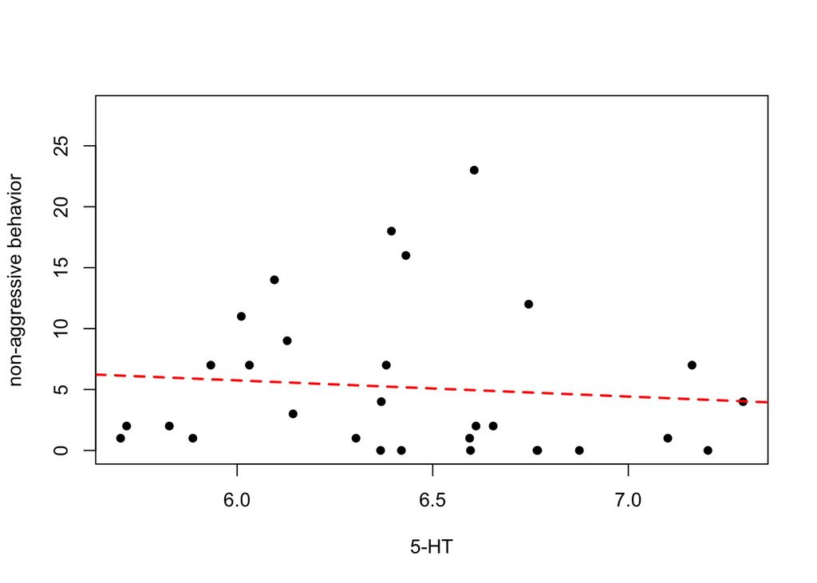

```r
plot(X5.HT.brain.mass, non.agg.freq,pch=16,
               xlab="5-HT",
               ylab="non-aggressive behavior")
abline(coefficients(reg1), lwd=2, lty=2,
       col="red")
```

```r
reg2 <- lm(non.agg.freq~OA.brain.mass, data = f)
summary(reg2)
```

```
##
## Call:
## lm(formula = non.agg.freq ~ OA.brain.mass, data = f)
##
## Residuals:
##    Min     1Q Median     3Q    Max
## -5.398 -4.560 -3.038  2.867 17.676
##
## Coefficients:
##               Estimate Std. Error t value Pr(>|t|)
## (Intercept)     8.1362     8.4739   0.960    0.345
## OA.brain.mass  -0.6895     1.9495  -0.354    0.726
##
## Residual standard error: 6.277 on 28 degrees of freedom
##   (11 observations deleted due to missingness)
## Multiple R-squared:  0.004448,   Adjusted R-squared:  -0.03111
## F-statistic: 0.1251 on 1 and 28 DF,  p-value: 0.7262
```

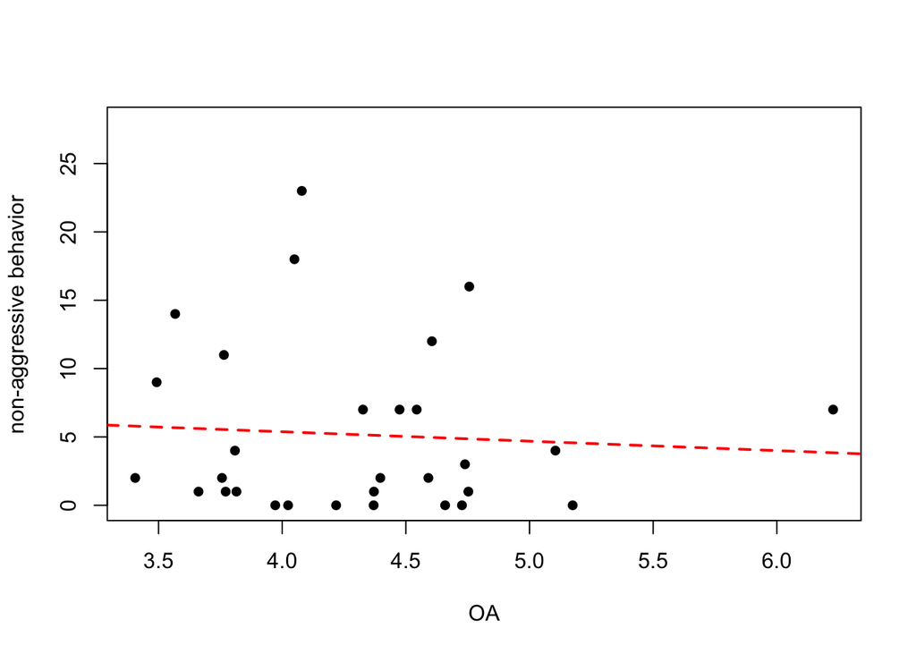

```r
plot(OA.brain.mass, non.agg.freq,pch=16,
               xlab="OA",
               ylab="non-aggressive behavior")
abline(coefficients(reg2), lwd=2, lty=2,
       col="red")
```

```r
reg3 <- lm(antennation~DA.brain.mass, data = f)
summary(reg3)
```

```
##
## Call:
## lm(formula = antennation ~ DA.brain.mass, data = f)
##
## Residuals:
##    Min     1Q Median     3Q    Max
## -4.163 -2.528 -1.424  2.251 10.755
##
## Coefficients:
##               Estimate Std. Error t value Pr(>|t|)
## (Intercept)     8.3806     4.9451   1.695    0.101
## DA.brain.mass  -0.4600     0.4522  -1.017    0.318
##
## Residual standard error: 3.791 on 28 degrees of freedom
##   (11 observations deleted due to missingness)
## Multiple R-squared:  0.03564,    Adjusted R-squared:  0.001195
## F-statistic: 1.035 on 1 and 28 DF,  p-value: 0.3178
```

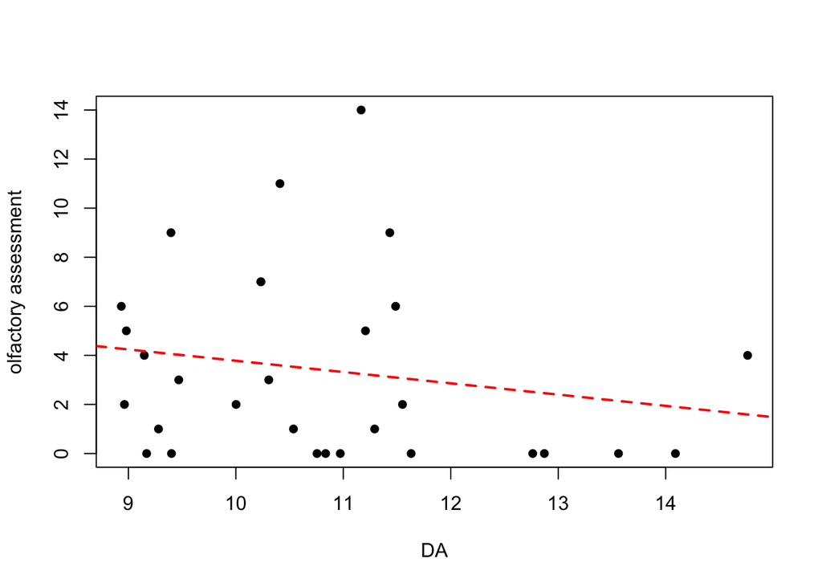

```r
plot(DA.brain.mass, antennation,pch=16,
               xlab="DA",
               ylab="olfactory assessment")
abline(coefficients(reg3), lwd=2, lty=2,
       col="red")
```

```r
reg4 <- lm(antennation~X5.HT.brain.mass, data = f)
summary(reg4)
```

```
##
## Call:
## lm(formula = antennation ~ X5.HT.brain.mass, data = f)
##
## Residuals:
##    Min     1Q Median     3Q    Max
## -3.532 -3.326 -1.335  2.306 10.630
##
## Coefficients:
##                  Estimate Std. Error t value Pr(>|t|)
## (Intercept)        4.5569    10.5070   0.434    0.668
## X5.HT.brain.mass  -0.1797     1.6285  -0.110    0.913
##
## Residual standard error: 3.859 on 28 degrees of freedom
##   (11 observations deleted due to missingness)
## Multiple R-squared:  0.0004347,  Adjusted R-squared:  -0.03526
## F-statistic: 0.01218 on 1 and 28 DF,  p-value: 0.9129
```

[figure not shown]

```r
plot(X5.HT.brain.mass, antennation,pch=16,
               xlab="DA",
               ylab="olfactory assessment")
abline(coefficients(reg4), lwd=2, lty=2,
       col="red")
```

```r
reg5 <- lm(antennation~OA.brain.mass, data = f)
summary(reg5)
```

```
##
## Call:
## lm(formula = antennation ~ OA.brain.mass, data = f)
##
## Residuals:
##    Min     1Q Median     3Q    Max
## -3.864 -2.867 -1.061  1.731 10.844
##
## Coefficients:
##               Estimate Std. Error t value Pr(>|t|)
## (Intercept)     -1.218      5.136  -0.237    0.814
## OA.brain.mass    1.072      1.182   0.907    0.372
##
## Residual standard error: 3.805 on 28 degrees of freedom
##   (11 observations deleted due to missingness)
## Multiple R-squared:  0.02857,    Adjusted R-squared:  -0.006122
## F-statistic: 0.8236 on 1 and 28 DF,  p-value: 0.3719
```

[figure not shown]

```r
plot(OA.brain.mass, antennation,pch=16,
               xlab="DA",
               ylab="olfactory assessment")
abline(coefficients(reg5), lwd=2, lty=2,
       col="red")
```

```r
reg6 <- lm(agg.freq~DA.brain.mass, data = f)
summary(reg6)
```

```
##
## Call:
## lm(formula = agg.freq ~ DA.brain.mass, data = f)
##
## Residuals:
##    Min     1Q Median     3Q    Max
## -5.979 -4.080 -2.109  3.443 13.969
##
## Coefficients:
##               Estimate Std. Error t value Pr(>|t|)
## (Intercept)    -1.4245     7.0078  -0.203     0.84
## DA.brain.mass   0.5964     0.6408   0.931     0.36
##
## Residual standard error: 5.372 on 28 degrees of freedom
##   (11 observations deleted due to missingness)
## Multiple R-squared:  0.03001,    Adjusted R-squared:  -0.004637
## F-statistic: 0.8662 on 1 and 28 DF,  p-value: 0.36
```

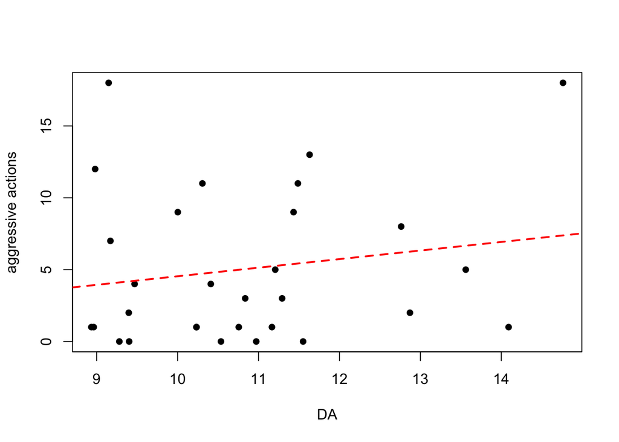

```r
plot(DA.brain.mass, agg.freq,pch=16,
               xlab="DA",
               ylab="aggressive actions")
abline(coefficients(reg6), lwd=2, lty=2,
       col="red")
```

```r
reg7 <- lm(agg.freq~X5.HT.brain.mass, data = f)
summary(reg7)
```

```
##
## Call:
## lm(formula = agg.freq ~ X5.HT.brain.mass, data = f)
##
## Residuals:
##    Min     1Q Median     3Q    Max
## -5.136 -4.069 -2.004  3.695 13.049
##
## Coefficients:
##                  Estimate Std. Error t value Pr(>|t|)
## (Intercept)        6.2395    14.8478   0.420    0.678
## X5.HT.brain.mass  -0.1874     2.3013  -0.081    0.936
##
## Residual standard error: 5.454 on 28 degrees of freedom
##   (11 observations deleted due to missingness)
## Multiple R-squared:  0.0002367,  Adjusted R-squared:  -0.03547
## F-statistic: 0.006629 on 1 and 28 DF,  p-value: 0.9357
```

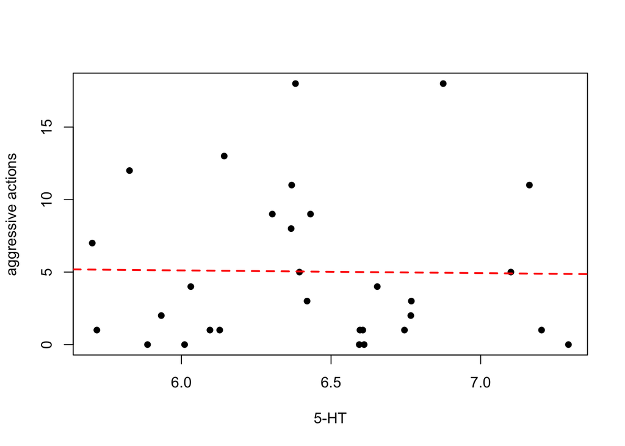

```r
plot(X5.HT.brain.mass, agg.freq,pch=16,
               xlab="5-HT",
               ylab="aggressive actions")
abline(coefficients(reg7), lwd=2, lty=2,
       col="red")
```

```r
reg8 <- lm(agg.freq~OA.brain.mass, data = f)
summary(reg8)
```

```
##
## Call:
## lm(formula = agg.freq ~ OA.brain.mass, data = f)
##
## Residuals:
##    Min     1Q Median     3Q    Max
## -5.776 -2.353 -1.323  1.443 12.851
##
## Coefficients:
##               Estimate Std. Error t value Pr(>|t|)
## (Intercept)    -20.115      5.586  -3.601  0.00121 **
## OA.brain.mass    5.839      1.285   4.544 9.65e-05 ***
## ---
## Signif. codes:  0 '***' 0.001 '**' 0.01 '*' 0.05 '.' 0.1 ' ' 1
##
## Residual standard error: 4.138 on 28 degrees of freedom
##   (11 observations deleted due to missingness)
## Multiple R-squared:  0.4244, Adjusted R-squared:  0.4038
## F-statistic: 20.64 on 1 and 28 DF,  p-value: 9.651e-05
```

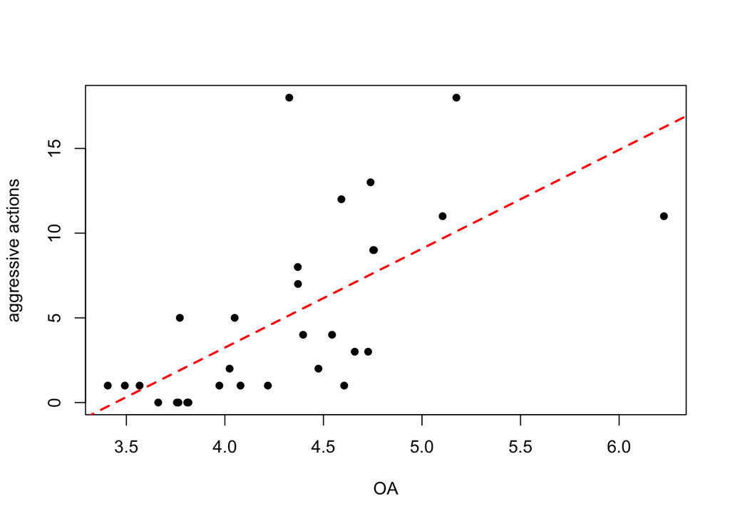

```r
plot(OA.brain.mass, agg.freq,pch=16,
               xlab="OA",
               ylab="aggressive actions")
abline(coefficients(reg8), lwd=2, lty=2,
       col="red")
```

```r
i <- read.csv("https://raw.githubusercontent.com/frankazorsa/AN597_replication-project/master/epn_treatments.csv?token=ANEFADVZ42HWFRGK4GPAKHS57AX6W")
i
```

```
##        ID date.tested subcaste focal.colony  treatment stimulus.colony avoid
## 1   EPN20     8_10_14    major       JC_D14 epinastine          JC_E14     0
## 2   EPN21     8_10_14    major       JC_D14 epinastine          JC_E14     1
## 3   EPN22     8_10_14    major       JC_D14 epinastine          JC_E14     2
## 4   EPN23     8_10_14    major       JC_D14 epinastine          JC_E14     2
## 5   EPN24     8_10_14    major       JC_D14 epinastine          JC_E14     0
## 6   EPN25     8_10_14    major       JC_D14 epinastine          JC_E14     1
## 7   EPN27     8_11_14    major       JC_E14 epinastine            JC_4     0
## 8   EPN28     8_11_14    major       JC_E14 epinastine            JC_4     0
## 9   EPN29     8_11_14    major       JC_E14 epinastine            JC_4     0
## 10  EPN30     8_11_14    major       JC_E14 epinastine            JC_4     6
## 11  EPN31     8_11_14    major       JC_E14 epinastine            JC_4     0
## 12  EPN32     8_11_14    major       JC_E14 epinastine            JC_4     0
## 13  EPN33     8_11_14    major       JC_E14 epinastine            JC_4     0
## 14 CONT10     8_12_14    major       JC_D14    control          JC_E14     0
```

[output cut: 99 more lines]

```r
t.test(i$movement.line.crosses ~ i$treatment)#t-test, to determine whether the means of two groups are equal to each other
```

```
##
##  Welch Two Sample t-test
##
## data:  i$movement.line.crosses by i$treatment
## t = -1.2063, df = 34.682, p-value = 0.2359
## alternative hypothesis: true difference in means is not equal to 0
## 95 percent confidence interval:
##  -18.989998   4.837057
## sample estimates:
##    mean in group control mean in group epinastine
##                 16.10000                 23.17647
```

```r
names(i)
```

```
##  [1] "ID"                    "date.tested"           "subcaste"
##  [4] "focal.colony"          "treatment"             "stimulus.colony"
##  [7] "avoid"                 "no.response"           "antennation"
## [10] "flared"                "raised.gaster"         "lunge"
## [13] "bite"                  "non.agg.freq"          "agg.freq"
## [16] "movement.line.crosses" "agg.metric"
```

```r
j <- subset(i, treatment=="control")
j
```

```
##        ID date.tested subcaste focal.colony treatment stimulus.colony avoid
## 14 CONT10     8_12_14    major       JC_D14   control          JC_E14     0
## 15 CONT11     8_12_14    major       JC_D14   control          JC_E14     0
## 16 CONT12     8_12_14    major       JC_D14   control          JC_E14     0
## 17 CONT15     8_12_14    major       JC_D14   control          JC_E14     1
## 18 CONT16     8_12_14    major       JC_D14   control          JC_E14     1
## 19 CONT17     8_14_14    major       JC_E14   control            JC_4     0
## 20 CONT18     8_14_14    major       JC_E14   control            JC_4     0
## 21 CONT19     8_14_14    major       JC_E14   control            JC_4     0
## 22 CONT20     8_14_14    major       JC_E14   control            JC_4     0
## 23 CONT21     8_14_14    major       JC_E14   control            JC_4     0
## 24 CONT22     8_14_14    major       JC_E14   control            JC_4     0
## 25 CONT23     8_14_14    major       JC_E14   control            JC_4     0
## 30 CONT25     8_22_14    major       JC_D14   control          JC_F14     0
## 31 CONT26     8_22_14    major       JC_D14   control          JC_F14     0
```

[output cut: 48 more lines]

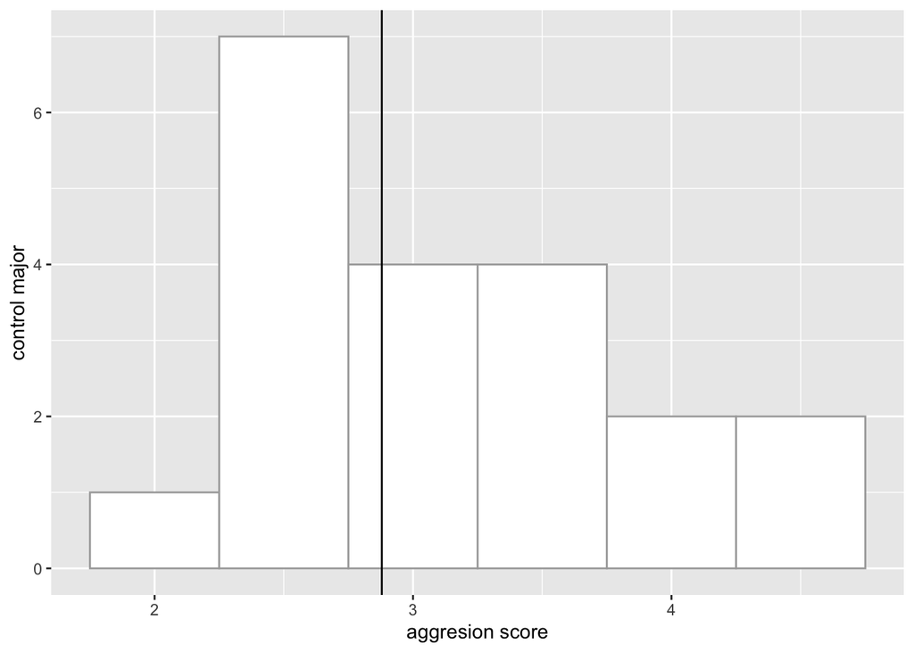

```r
ggplot (j, aes(agg.metric)) +
  geom_histogram(color = "darkgray", fill ="white", binwidth = .5) +
  labs(x="aggresion score", y="control major") +
  geom_vline(aes(xintercept = mean(i$agg.metric, na.rm = TRUE)))
```

```r
k <- subset(i, treatment=="epinastine")
k
```

```
##       ID date.tested subcaste focal.colony  treatment stimulus.colony avoid
## 1  EPN20     8_10_14    major       JC_D14 epinastine          JC_E14     0
## 2  EPN21     8_10_14    major       JC_D14 epinastine          JC_E14     1
## 3  EPN22     8_10_14    major       JC_D14 epinastine          JC_E14     2
## 4  EPN23     8_10_14    major       JC_D14 epinastine          JC_E14     2
## 5  EPN24     8_10_14    major       JC_D14 epinastine          JC_E14     0
## 6  EPN25     8_10_14    major       JC_D14 epinastine          JC_E14     1
## 7  EPN27     8_11_14    major       JC_E14 epinastine            JC_4     0
## 8  EPN28     8_11_14    major       JC_E14 epinastine            JC_4     0
## 9  EPN29     8_11_14    major       JC_E14 epinastine            JC_4     0
## 10 EPN30     8_11_14    major       JC_E14 epinastine            JC_4     6
## 11 EPN31     8_11_14    major       JC_E14 epinastine            JC_4     0
## 12 EPN32     8_11_14    major       JC_E14 epinastine            JC_4     0
## 13 EPN33     8_11_14    major       JC_E14 epinastine            JC_4     0
## 26 EPN35     8_21_14    major       JC_D14 epinastine          JC_F14     0
```

[output cut: 39 more lines]

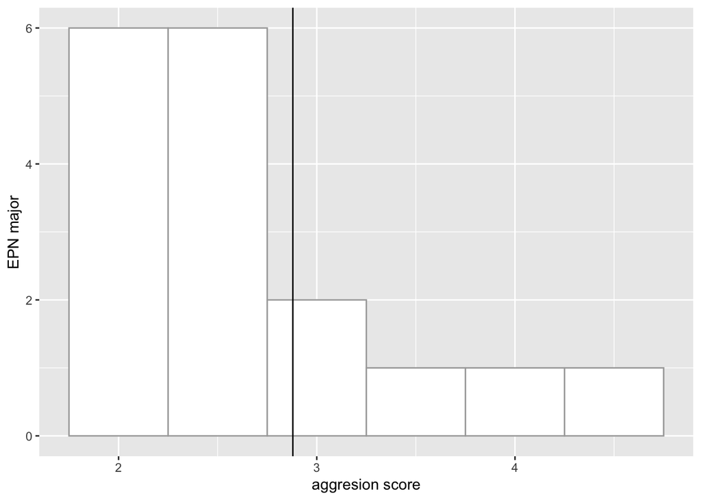

```r
ggplot (k, aes(agg.metric)) +
  geom_histogram(color = "darkgray", fill ="white", binwidth = .5) +
  labs(x="aggresion score", y="EPN major") +
  geom_vline(aes(xintercept = mean(i$agg.metric, na.rm = TRUE)))
```

```r
names(i)
```

```
##  [1] "ID"                    "date.tested"           "subcaste"
##  [4] "focal.colony"          "treatment"             "stimulus.colony"
##  [7] "avoid"                 "no.response"           "antennation"
## [10] "flared"                "raised.gaster"         "lunge"
## [13] "bite"                  "non.agg.freq"          "agg.freq"
## [16] "movement.line.crosses" "agg.metric"
```

```r
library(dplyr)
library(ggplot2)
cleandata5 <- i %>%
  group_by (treatment) %>%
  summarise (mean_non.agg.freq = mean(non.agg.freq, na.rm = TRUE),
             mean_antennation = mean(antennation, na.rm = TRUE),
             mean_agg.freq = mean(agg.freq, na.rm = TRUE),
             sd_non.agg.freq = sd(non.agg.freq, na.rm = TRUE),
             sd_antennation = sd(antennation, na.rm = TRUE),
             sd_agg.freq = sd(agg.freq, na.rm = TRUE),
             count=n(),
             se_non.agg.freq = (sd_non.agg.freq/(sqrt(count))),
             se_antennation = (sd_antennation/(sqrt(count))),
             se_agg.freq = (sd_agg.freq/(sqrt(count))))
cleandata5
```

```
## # A tibble: 2 x 11
##   treatment mean_non.agg.fr… mean_antennation mean_agg.freq sd_non.agg.freq
##   <fct>                <dbl>            <dbl>         <dbl>           <dbl>
## 1 control              0.7               6.3          12.7             1.22
## 2 epinasti…            0.824             7.24          6.35            1.51
## # … with 6 more variables: sd_antennation <dbl>, sd_agg.freq <dbl>,
## #   count <int>, se_non.agg.freq <dbl>, se_antennation <dbl>, se_agg.freq <dbl>
```

```r
means2 <- aggregate(cleandata5, by=list(cleandata5$treatment), mean)
means2
```

```
##      Group.1 treatment mean_non.agg.freq mean_antennation mean_agg.freq
## 1    control        NA         0.7000000         6.300000     12.700000
## 2 epinastine        NA         0.8235294         7.235294      6.352941
##   sd_non.agg.freq sd_antennation sd_agg.freq count se_non.agg.freq
## 1        1.218282       2.848822   19.123147    20       0.2724161
## 2        1.509772       4.548755    8.169617    17       0.3661735
##   se_antennation se_agg.freq
## 1      0.6370161    4.276066
## 2      1.1032353    1.981423
```

```r
means2$treatment <- NULL
means2
```

```
##      Group.1 mean_non.agg.freq mean_antennation mean_agg.freq sd_non.agg.freq
## 1    control         0.7000000         6.300000     12.700000        1.218282
## 2 epinastine         0.8235294         7.235294      6.352941        1.509772
##   sd_antennation sd_agg.freq count se_non.agg.freq se_antennation se_agg.freq
## 1       2.848822   19.123147    20       0.2724161      0.6370161    4.276066
## 2       4.548755    8.169617    17       0.3661735      1.1032353    1.981423
```

```r
names(means2)[names(means2) == 'Group.1'] <- 'treatment'
means2
```

```
##    treatment mean_non.agg.freq mean_antennation mean_agg.freq sd_non.agg.freq
## 1    control         0.7000000         6.300000     12.700000        1.218282
## 2 epinastine         0.8235294         7.235294      6.352941        1.509772
##   sd_antennation sd_agg.freq count se_non.agg.freq se_antennation se_agg.freq
## 1       2.848822   19.123147    20       0.2724161      0.6370161    4.276066
## 2       4.548755    8.169617    17       0.3661735      1.1032353    1.981423
```

```r
dataset3 <- means2[1:4]
dataset3
```

```
##    treatment mean_non.agg.freq mean_antennation mean_agg.freq
## 1    control         0.7000000         6.300000     12.700000
## 2 epinastine         0.8235294         7.235294      6.352941
```

```r
library(reshape2)
library(ggplot2)
dataset3
```

```
##    treatment mean_non.agg.freq mean_antennation mean_agg.freq
## 1    control         0.7000000         6.300000     12.700000
## 2 epinastine         0.8235294         7.235294      6.352941
```

```r
data.n <- melt(dataset3, id.vars='treatment')
data.n
```

```
##    treatment          variable      value
## 1    control mean_non.agg.freq  0.7000000
## 2 epinastine mean_non.agg.freq  0.8235294
## 3    control  mean_antennation  6.3000000
## 4 epinastine  mean_antennation  7.2352941
## 5    control     mean_agg.freq 12.7000000
## 6 epinastine     mean_agg.freq  6.3529412
```

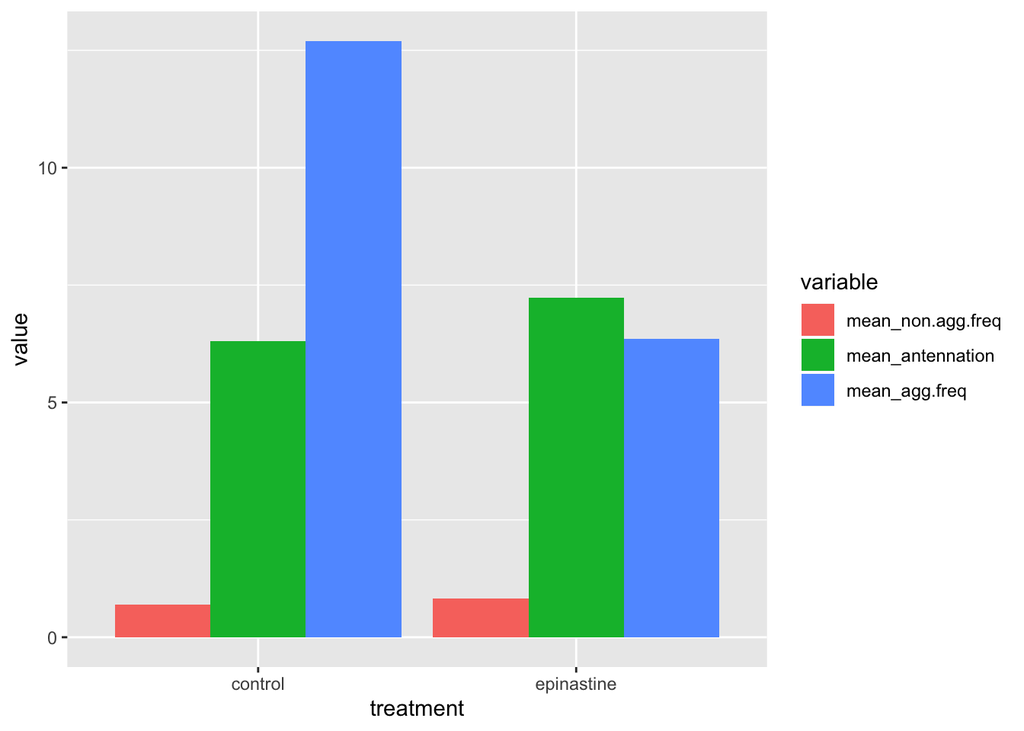

```r
ggplot(data = data.n, aes(x = treatment, y = value, fill = variable)) +
       geom_bar(stat = 'identity', position = 'dodge')
```

### Figure 5 a, c

```r
l <- read.csv("https://raw.githubusercontent.com/frankazorsa/AN597_replication-project/master/oa_treatments.csv?token=ANEFADRFRK44IJ7IIALGXP257AYA4")
l
```

```
##       ID date.tested subcaste focal.colony  treatment time.tested
## 1   CNT1    10_15_14    minor         OS_B    control          15
## 2   CNT2    10_15_14    minor         OS_B    control          15
## 3   CNT3    10_15_14    minor         OS_B    control          25
## 4   CNT4    10_15_14    minor         OS_B    control          20
## 5    OA1    10_15_14    minor         OS_B OA topical          24
## 6    OA2    10_15_14    minor         OS_B OA topical          24
## 7    OA3    10_15_14    minor         OS_B OA topical          15
## 8    OA4    10_15_14    minor         OS_B OA topical          17
## 9   CNT5    10_21_14    minor         OS_B    control          15
## 10   OA5    10_21_14    minor         OS_B OA topical          22
## 11   OA6    10_21_14    minor         OS_B OA topical          15
## 12  CNT6    10_21_14    minor         OS_B    control          28
## 13  CNT7    10_21_14    minor         OS_B    control          15
## 14   OA7    10_21_14    minor         OS_B OA topical          22
```

[output cut: 272 more lines]

```r
t.test(l$movement.line.crosses ~ l$treatment)#t-test, to determine whether the means of two groups are equal to each other
```

```
##
##  Welch Two Sample t-test
##
## data:  l$movement.line.crosses by l$treatment
## t = 1.4024, df = 26.865, p-value = 0.1722
## alternative hypothesis: true difference in means is not equal to 0
## 95 percent confidence interval:
##  -3.112738 16.546071
## sample estimates:
##    mean in group control mean in group OA topical
##                 15.66667                  8.95000
```

```r
names(l)
```

```
##  [1] "ID"                             "date.tested"
##  [3] "subcaste"                       "focal.colony"
##  [5] "treatment"                      "time.tested"
##  [7] "time.dissected"                 "stimulus.colony"
##  [9] "raw.headwidth"                  "headwidth..mm."
## [11] "estimated.brain.mass"           "DA.raw"
## [13] "DA.corrected"                   "DA.brain.mass"
## [15] "X5.HT.raw"                      "X5.HT.corrected"
## [17] "X5.HT.brain.mass"               "OA.raw"
## [19] "OA.corrected"                   "OA.brain.mass"
## [21] "OA.brain.mass.without.excluded" "avoid"
## [23] "no.response"                    "antennation"
## [25] "flared"                         "raised.gaster"
## [27] "lunge"                          "bite"
## [29] "non.agg.freq"                   "agg.freq"
## [31] "agg.metric"                     "movement.line.crosses"
```

```r
m <- subset(l, treatment=="control")
m
```

```
##       ID date.tested subcaste focal.colony treatment time.tested time.dissected
## 1   CNT1    10_15_14    minor         OS_B   control          15             60
## 2   CNT2    10_15_14    minor         OS_B   control          15             60
## 3   CNT3    10_15_14    minor         OS_B   control          25             49
## 4   CNT4    10_15_14    minor         OS_B   control          20             46
## 9   CNT5    10_21_14    minor         OS_B   control          15             55
## 12  CNT6    10_21_14    minor         OS_B   control          28             49
## 13  CNT7    10_21_14    minor         OS_B   control          15             52
## 16  CNT8    10_21_14    minor         OS_B   control          16             55
## 19  CNT9    10_21_14    minor         OS_B   control          15             60
## 20 CNT10    10_21_14    minor         OS_B   control          15             38
## 21 CNT11    10_22_14    minor         OS_H   control          15             54
## 24 CNT12    10_22_14    minor         OS_H   control          24             54
## 25 CNT13    10_22_14    minor         OS_H   control          15             45
## 28 CNT14    10_22_14    minor         OS_H   control          15             52
```

[output cut: 111 more lines]

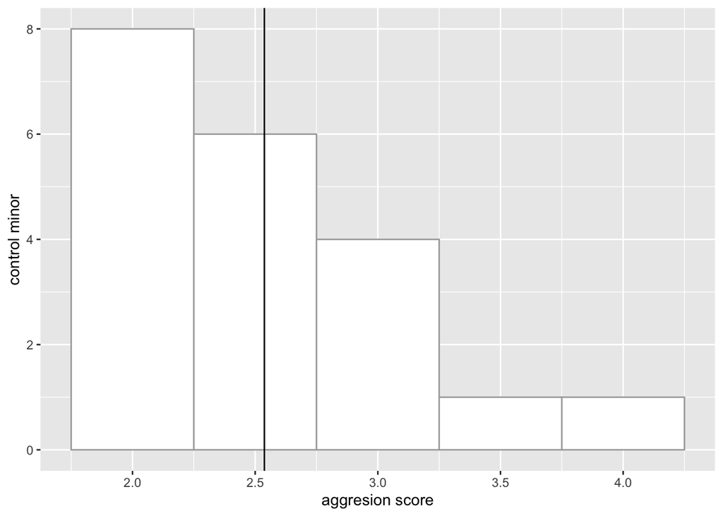

```r
ggplot (m, aes(agg.metric)) +
  geom_histogram(color = "darkgray", fill ="white", binwidth = .5) +
  labs(x="aggresion score", y="control minor") +
  geom_vline(aes(xintercept = mean(l$agg.metric, na.rm = TRUE)))
```

```r
n <- subset(l, treatment=="OA topical")
n
```

```
##      ID date.tested subcaste focal.colony  treatment time.tested time.dissected
## 5   OA1    10_15_14    minor         OS_B OA topical          24             51
## 6   OA2    10_15_14    minor         OS_B OA topical          24             52
## 7   OA3    10_15_14    minor         OS_B OA topical          15             55
## 8   OA4    10_15_14    minor         OS_B OA topical          17             57
## 10  OA5    10_21_14    minor         OS_B OA topical          22             48
## 11  OA6    10_21_14    minor         OS_B OA topical          15             55
## 14  OA7    10_21_14    minor         OS_B OA topical          22             46
## 15  OA8    10_21_14    minor         OS_B OA topical          15             45
## 17  OA9    10_21_14    minor         OS_B OA topical          21             45
## 18 OA10    10_21_14    minor         OS_B OA topical          23             47
## 22 OA11    10_22_14    minor         OS_H OA topical          20             44
## 23 OA12    10_22_14    minor         OS_H OA topical          15             60
## 26 OA14    10_22_14    minor         OS_H OA topical          15             57
## 27 OA15    10_22_14    minor         OS_H OA topical          24             48
```

[output cut: 111 more lines]

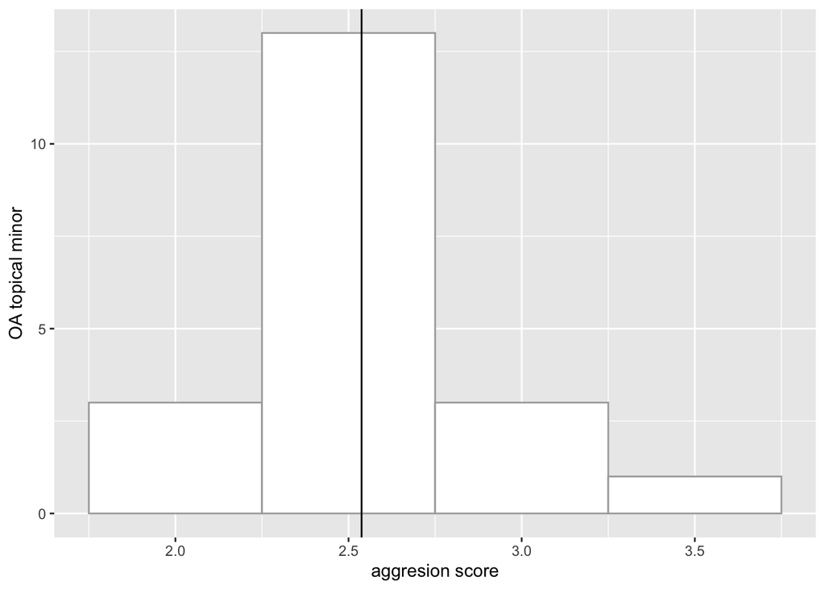

```r
ggplot (n, aes(agg.metric)) +
  geom_histogram(color = "darkgray", fill ="white", binwidth = .5) +
  labs(x="aggresion score", y="OA topical minor") +
  geom_vline(aes(xintercept = mean(l$agg.metric, na.rm = TRUE)))
```

```r
names(l)
```

```
##  [1] "ID"                             "date.tested"
##  [3] "subcaste"                       "focal.colony"
##  [5] "treatment"                      "time.tested"
##  [7] "time.dissected"                 "stimulus.colony"
##  [9] "raw.headwidth"                  "headwidth..mm."
## [11] "estimated.brain.mass"           "DA.raw"
## [13] "DA.corrected"                   "DA.brain.mass"
## [15] "X5.HT.raw"                      "X5.HT.corrected"
## [17] "X5.HT.brain.mass"               "OA.raw"
## [19] "OA.corrected"                   "OA.brain.mass"
## [21] "OA.brain.mass.without.excluded" "avoid"
## [23] "no.response"                    "antennation"
## [25] "flared"                         "raised.gaster"
## [27] "lunge"                          "bite"
## [29] "non.agg.freq"                   "agg.freq"
## [31] "agg.metric"                     "movement.line.crosses"
```

```r
library(dplyr)
library(ggplot2)
cleandata5 <- l %>%
  group_by (treatment) %>%
  summarise (mean_non.agg.freq = mean(non.agg.freq, na.rm = TRUE),
             mean_antennation = mean(antennation, na.rm = TRUE),
             mean_agg.freq = mean(agg.freq, na.rm = TRUE),
             sd_non.agg.freq = sd(non.agg.freq, na.rm = TRUE),
             sd_antennation = sd(antennation, na.rm = TRUE),
             sd_agg.freq = sd(agg.freq, na.rm = TRUE),
             count=n(),
             se_non.agg.freq = (sd_non.agg.freq/(sqrt(count))),
             se_antennation = (sd_antennation/(sqrt(count))),
             se_agg.freq = (sd_agg.freq/(sqrt(count))))
cleandata5
```

```
## # A tibble: 2 x 11
##   treatment mean_non.agg.fr… mean_antennation mean_agg.freq sd_non.agg.freq
##   <fct>                <dbl>            <dbl>         <dbl>           <dbl>
## 1 control               2.7              14.6          10.4            4.38
## 2 OA topic…             1.65             13.4          16.7            1.90
## # … with 6 more variables: sd_antennation <dbl>, sd_agg.freq <dbl>,
## #   count <int>, se_non.agg.freq <dbl>, se_antennation <dbl>, se_agg.freq <dbl>
```

```r
means2 <- aggregate(cleandata5, by=list(cleandata5$treatment), mean)
means2
```

```
##      Group.1 treatment mean_non.agg.freq mean_antennation mean_agg.freq
## 1    control        NA              2.70            14.65         10.45
## 2 OA topical        NA              1.65            13.35         16.70
##   sd_non.agg.freq sd_antennation sd_agg.freq count se_non.agg.freq
## 1        4.378176       8.099870   10.718773    20       0.9789898
## 2        1.899446       7.471173    9.814597    20       0.4247290
##   se_antennation se_agg.freq
## 1       1.811186    2.396791
## 2       1.670605    2.194611
```

```r
means2$treatment <- NULL
means2
```

```
##      Group.1 mean_non.agg.freq mean_antennation mean_agg.freq sd_non.agg.freq
## 1    control              2.70            14.65         10.45        4.378176
## 2 OA topical              1.65            13.35         16.70        1.899446
##   sd_antennation sd_agg.freq count se_non.agg.freq se_antennation se_agg.freq
## 1       8.099870   10.718773    20       0.9789898       1.811186    2.396791
## 2       7.471173    9.814597    20       0.4247290       1.670605    2.194611
```

```r
names(means2)[names(means2) == 'Group.1'] <- 'treatment'
means2
```

```
##    treatment mean_non.agg.freq mean_antennation mean_agg.freq sd_non.agg.freq
## 1    control              2.70            14.65         10.45        4.378176
## 2 OA topical              1.65            13.35         16.70        1.899446
##   sd_antennation sd_agg.freq count se_non.agg.freq se_antennation se_agg.freq
## 1       8.099870   10.718773    20       0.9789898       1.811186    2.396791
## 2       7.471173    9.814597    20       0.4247290       1.670605    2.194611
```

```r
dataset3 <- means2[1:4]
dataset3
```

```
##    treatment mean_non.agg.freq mean_antennation mean_agg.freq
## 1    control              2.70            14.65         10.45
## 2 OA topical              1.65            13.35         16.70
```

```r
library(reshape2)
library(ggplot2)
dataset3
```

```
##    treatment mean_non.agg.freq mean_antennation mean_agg.freq
## 1    control              2.70            14.65         10.45
## 2 OA topical              1.65            13.35         16.70
```

```r
data.n <- melt(dataset3, id.vars='treatment')
data.n
```

```
##    treatment          variable value
## 1    control mean_non.agg.freq  2.70
## 2 OA topical mean_non.agg.freq  1.65
## 3    control  mean_antennation 14.65
## 4 OA topical  mean_antennation 13.35
## 5    control     mean_agg.freq 10.45
## 6 OA topical     mean_agg.freq 16.70
```

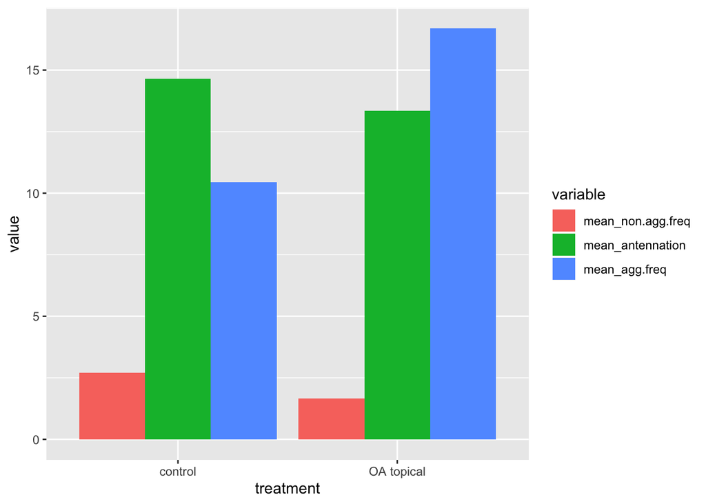

```r
ggplot(data = data.n, aes(x = treatment, y = value, fill = variable)) +
       geom_bar(stat = 'identity', position = 'dodge')
```

### Non-parametric Mann – Whitney U-tests

```r
names(f)
```

```
##  [1] "ID"                   "subcaste"             "focal.colony"
##  [4] "head.width..mm."      "estimated.brain.mass" "DA.corrected"
##  [7] "DA.brain.mass"        "X5.HT.corrected"      "X5.HT.brain.mass"
## [10] "OA.corrected"         "OA.brain.mass"        "avoid"
## [13] "no.response"          "antennation"          "flared"
## [16] "raised.gaster"        "lunge"                "bite"
## [19] "non.agg.freq"         "agg.freq"             "agg.metric"
```

```r
wilcox.test(agg.freq ~ subcaste, mu=0, alt="two.sided", conf.int=T, conf.level=0.95, paired=F, exact=F, correct=T)
```

```
##
##  Wilcoxon rank sum test with continuity correction
##
## data:  agg.freq by subcaste
## W = 347, p-value = 0.0001502
## alternative hypothesis: true location shift is not equal to 0
## 95 percent confidence interval:
##  2.999933 8.999983
## sample estimates:
## difference in location
##               6.000012
```

```r
wilcox.test(agg.metric ~ subcaste, mu=0, alt="two.sided", conf.int=T, conf.level=0.95, paired=F, exact=F, correct=T)
```

```
##
##  Wilcoxon rank sum test with continuity correction
##
## data:  agg.metric by subcaste
## W = 344, p-value = 5.101e-05
## alternative hypothesis: true location shift is not equal to 0
## 95 percent confidence interval:
##  1.071514 2.555616
## sample estimates:
## difference in location
##               1.968007
```

```r
wilcox.test(non.agg.freq ~ subcaste, mu=0, alt="two.sided", conf.int=T, conf.level=0.95, paired=F, exact=F, correct=T)
```

```
##
##  Wilcoxon rank sum test with continuity correction
##
## data:  non.agg.freq by subcaste
## W = 171.5, p-value = 0.3935
## alternative hypothesis: true location shift is not equal to 0
## 95 percent confidence interval:
##  -8.999955  2.000036
## sample estimates:
## difference in location
##               -1.00002
```

```r
wilcox.test(antennation ~ subcaste, mu=0, alt="two.sided", conf.int=T, conf.level=0.95, paired=F, exact=F, correct=T)
```

```
##
##  Wilcoxon rank sum test with continuity correction
##
## data:  antennation by subcaste
## W = 223.5, p-value = 0.6107
## alternative hypothesis: true location shift is not equal to 0
## 95 percent confidence interval:
##  -1.999920  2.999999
## sample estimates:
## difference in location
##           2.172664e-05
```